# Superfarmer

Marianna Dzik & Piotr Radziński

25.10.2016r.

## Wstęp

Celem naszego projektu jest stworzenie symulatora gry w Superfarmer dla pojedyńczego gracza wraz z autorską strategią. Następnie liczymy szacowany czas gry na zadanej próbce n gier. W poniższym raporcie przedstawimy działanie projektu krok po kroku.

## Nasza Strategia

Każdy farmer wie, że podstawą zróżnicowanego gospodarstwa są tylko i wyłącznie króliki. I psy, ale tych mniej. Niemniej gdy królików jest więcej niż klatek, spoglądając na przywódców wschodnich krain fajnie jest dosiadać konia.

Naszą strategię dzielimy na dwie fazy:

Faza I

Gdy nie mamy konia, naszym celem jest oczywiście go mieć! I czynimy tak gdy tylko jest to możliwe. Wcześniej, chcemy mieć jak najwięcej królików. Dbamy oczywiście o ich bezpieczeństwo za pomocą małego psa, bądź nawet dwóch (gdyby wilk nam zjadł króliczki to za coś chcemy je od niego odkupić). Dbamy oczywiście o dobre warunki do rozmnażania się dla królików, aby nie zabrakło dla nich miejsca (ot, czasem trochę baraniny).

Faza II

Mamy konia! Czego wtedy chce każdy zachłanny farmer? Oczywiście drugiego. Strategia bardzo się nie zmienia: Zwracamy troszkę więcej uwaga na co zamieniamy nadmiary królików i nie chcemy trzymać w zagrodzie zbyt dużo niepotrzebnych pysków do żarcia. Staramy się zatem już dążyć do posiadania każdego zwierzaka po jednym. Jeśli brakowało by nam i owiec i świń i wielu innych przyjaznych i puszystych zwierzaczków, ale stać nas by było na drugiego konia, to my bardzo chętnie! W końcu każdy superfarmer wie, że konie są nieśmiertelne! Gdy mamy dwa konie, oczywiście zamieniamy jednego z nich na całe stato zwierzaczków aby cieszyć się chwałą słowiańskiego rolnika.

## Sposób losowania

Do losowania wykorzystujemy funkcji sample. Jest ona bardzo wygodna w przypadku losowania kostką wielościenną, na której może być kilka tych samych zwierząt, gdyż pozwala nam wybrać prawdopodobieństwo z jakim dostaniemy konkretne zwierze. Aby ułatwić dalsze obliczenia zawsze losujemy spośród wszystkich możliwych zwierząt, lecz te, które nie możemy otrzymać z danej kostki mają prawdopodobieństwo 0.

## Kod:

```r
#Ustalamy potrzebne nam stałe:
n=10000
dlugosc_gry = 1:n
kostka_lis_al = 1:n
kostka_wilk_al = 1:n

kon = 1
krowa = 2
swinia = 3
owca = 4
krolik = 5
duzy_pies = 6
maly_pies = 7
lis = 8
wilk = 9

lockBinding("kon", globalenv())
lockBinding("krowa", globalenv())
lockBinding("swinia", globalenv())
lockBinding("owca", globalenv())
lockBinding("krolik", globalenv())
lockBinding("maly_pies", globalenv())
lockBinding("duzy_pies", globalenv())
lockBinding("lis", globalenv())
lockBinding("wilk", globalenv())

limit = c(6, 12, 20, 24, 60, 2, 4)
lockBinding("limit", globalenv())

for (i in 1:n){

  stado = rep(0, times=7)

  x = 0
  licznik = 0

  repeat{
    licznik = licznik + 1

# Ile jest warte nasze stado?
    x= stado[krolik] + 6*stado[owca] + 12*stado[swinia] + 36*stado[krowa] + 72*stado[kon] +36*stado[duzy_pies] + 6*stado[maly_pies]
    ruch = 0

# Faza I
    if (stado[kon] == 0)
    {

# Bierzemy pierwszego konia niczym chytra baba z Radomia.
      if (x >= 72 && ruch == 0)
      {
        stado[kon] = 1
        y = -72
        while (y < 0 && stado[krowa] > 0)
        {
          stado[krowa] = stado[krowa] - 1
          y = y + 36
        }
        while (y < 0 && stado[swinia] > 0)
        {
          stado[swinia] = stado[swinia] - 1
          y = y + 12
        }
        while (y < 0 && stado[owca] > 0)
        {
          stado[owca] = stado[owca] - 1
          y = y + 6
        }
        while (y < 0 && stado[maly_pies] > 0)
        {
          stado[maly_pies] = stado[maly_pies] - 1
          y = y + 6
        }
        while (y < 0 && stado[krolik] > 0)
        {
          stado[krolik] = stado[krolik] - 1
          y = y + 1
        }
        ruch = 1
      }

# Chcemy pierwszego małego psa...
      if (stado[maly_pies] == 0 && stado[krolik] > 9 && ruch == 0)
      {
        stado[krolik] = stado[krolik] - 6
        stado[maly_pies] = 1
        ruch = 1
      }

# ...i drugiego.
      if (stado[maly_pies] == 1 && stado[krolik] > 25 && ruch == 0)
      {
        stado[krolik] = stado[krolik] - 6
        stado[maly_pies] = stado[maly_pies] + 1
        ruch = 1
      }

# Jeśli los przyniusł mam owce i świnie to my i tach chcemy mieć więcej królikóW! (o ile mamy dla nich klatki)
        if (stado[krolik]  < 27 && stado[swinia] > 0 && ruch == 0)
        {
          stado[krolik] = stado[krolik] + 12
          stado[swinia] = stado[swinia] - 1
          ruch = 1
        }
         if (stado[krolik]  < 33 && stado[owca] > 0 && ruch == 0)
        {
          stado[krolik] = stado[krolik] + 6
          stado[owca] = stado[owca] - 1
          ruch = 1
        }

# W czasie biedy sprzedajemy małego psa za króliki.
      if (stado[krolik] == 0  && stado[maly_pies] > 0 && ruch == 0)
      {
        stado[krolik] = stado[krolik] + 6
        stado[maly_pies] = stado[maly_pies] - 1
        ruch = 1
      }
# Jak mamy za dużo królików to wymieniamy na owcę...
      if (45 > stado[krolik] && stado[krolik] > 39 && ruch == 0  && stado[owca] < 23)
      {
        stado[krolik] = stado[krolik] - 6
        stado[owca] = stado[owca] + 1
        ruch = 1
      }
# ...lub na świnię.
        if (46 < stado[krolik]  && ruch == 0  && stado[swinia] < 20)
      {
        stado[krolik] = stado[krolik] - 12
        stado[swinia] = stado[swinia] + 1
        ruch = 1
      }
    }


# Faza II
    if (stado[kon] == 1 && ruch == 0)
    {

# Dwa konie to pewna wygrana (za turę)!
      if (x >= 144 && ruch == 0)
      {
        stado[kon] = 2
        ruch = 1
        y = -72
        while (y < 0 && stado[krowa] > 0)
        {
          stado[krowa] = stado[krowa] - 1
          y = y + 36
        }
        while (y < 0 && stado[swinia] > 0)
        {
          stado[swinia] = stado[swinia] - 1
          y = y + 12
        }
        while (y < 0 && stado[owca] > 0)
        {
          stado[owca] = stado[owca] - 1
          y = y + 6
        }
        while (y < 0 && stado[maly_pies] > 0)
        {
          stado[maly_pies] = stado[maly_pies] - 1
          y = y + 6
        }
        while (y < 0 && stado[krolik] > 0)
        {
          stado[krolik] = stado[krolik] - 1
          y = y + 1
        }
        ruch = 1

      }

# Dość zwierząt aby skończyć, ale za mało na dwa ogiery.
      if (x >= 127 && ruch == 0)
      {
# Bawimy się w handel!:
# krowa -> króliki
        if (stado[krolik] == 0 && stado[krowa] > 1 && ruch == 0)
        {
           stado[krowa] = stado[krowa] - 1
           stado[krolik] = stado[krolik] + 36
           ruch = 1
        }
# krowa -> owce
       if (stado[owca] == 0 && stado[krowa] > 1 && ruch == 0)
        {
           stado[krowa] = stado[krowa] - 1
           stado[owca] = stado[owca] + 6
           ruch = 1
        }
# krowa -> świnie
       if (stado[swinia] == 0 && stado[krowa] > 1 && ruch == 0)
        {
           stado[krowa] = stado[krowa] - 1
           stado[swinia] = stado[swinia] + 3
           ruch = 1
        }
# świnia -> króliki
       if (stado[krolik] == 0 && stado[swinia] > 1 && ruch == 0)
        {
           stado[swinia] = stado[swinia] - 1
           stado[krolik] = stado[krolik] + 12
           ruch = 1
        }
# świnia -> owce
       if (stado[owca] == 0 && stado[swinia] > 1 && ruch == 0)
        {
           stado[swinia] = stado[swinia] - 1
           stado[owca] = stado[owca] + 2
           ruch = 1
        }
# owca -> króliki
        if (stado[krolik] == 0 && stado[owca] > 1 && ruch == 0)
        {
           stado[owca] = stado[owca] - 1
           stado[krolik] = stado[krolik] + 6
           ruch = 1
        }
# Chcemy owcę!
       if (stado[owca] == 0 && stado[krolik] > 6 && ruch == 0)
       {
          stado[owca] = 1
          stado[krolik] = stado[krolik] - 6
          ruch = 1
       }

# Chcemy świnię za wszelką cenę!
       if (stado[swinia] == 0 && ruch == 0)
      {
        stado[swinia] = 1
        ruch = 1
        y = -12
        while (y < 0 && stado[owca] > 1)
        {
          stado[owca] = stado[owca] - 1
          y = y + 6
        }
        while (y < 0 && stado[maly_pies] > 0)
        {
          stado[maly_pies] = stado[maly_pies] - 1
          y = y + 6
        }
        while (y < 0 && stado[krolik] > 1)
        {
          stado[krolik] = stado[krolik] - 1
          y = y + 1
        }
      }

# Chcemy krowę za wszelką cenę!
       if (stado[krowa] == 0 && ruch == 0)
      {
        stado[krowa] = 1
        ruch = 1
        y = -36
        while (y < 0 && stado[swinia] > 1)
        {
          stado[swinia] = stado[swinia] - 1
          y = y + 12
        }
        while (y < 0 && stado[owca] > 1)
        {
          stado[owca] = stado[owca] - 1
          y = y + 6
        }
        while (y < 0 && stado[maly_pies] > 0)
        {
          stado[maly_pies] = stado[maly_pies] - 1
          y = y + 6
        }
        while (y < 0 && stado[krolik] > 1)
        {
          stado[krolik] = stado[krolik] - 1
          y = y + 1
        }
      }
      }

# Rozmnażamy króliki aby mieć dość do kupienia całego stada.
      if (x < 127 && ruch == 0)
      {
          if (stado[maly_pies] == 0 && stado[krolik] > 9 && ruch ==0)
          {
            stado[krolik] = stado[krolik] - 6
            stado[maly_pies] = 1
            ruch =1
          }
          if (stado[krolik] == 0 && stado[maly_pies] > 0 && ruch == 0)
          {
            stado[krolik] = stado[krolik] + 6
            stado[maly_pies] = stado[maly_pies] - 1
            ruch = 1
          }
         if (stado[owca] == 0 && stado[krolik] > 15 && ruch == 0)
          {
            stado[krolik] = stado[krolik] - 6
            stado[owca] = 1
            ruch =1
          }
         if (stado[owca] > 0 && stado[krolik] > 20 && stado[swinia] == 0 && ruch == 0)
          {
            stado[krolik] = stado[krolik] - 12
            stado[swinia] = 1
            ruch =1
          }
      }
    }

# Czy mamy już wszystkie zwierzaczki?
    if (stado[kon] > 0 && stado[krowa] > 0 && stado[swinia] > 0 && stado[owca] > 0 && stado[krolik] > 0) break


# A może mamy dwa konie?
    if (stado[kon] > 1 && ruch == 0 )
    {
      stado[kon] = stado[kon] - 1
      stado[krowa] = stado[krowa] + 1
      stado[swinia] = stado[swinia] + 2
      stado[owca] = stado[owca] + 1
      if (stado[krolik] < 54){
        stado[krolik] = stado[krolik] + 6
      } else {
      stado[owca] = stado[owca] + 1
      }
      break
    }

#Losowanie kostka.

kostka_wilk = sample(1:9, 1, TRUE, prob=c(0, 1/12, 1/12, 1/4, 1/2, 0, 0, 0, 1/12))
kostka_lis = sample(1:9, 1, TRUE, prob=c(1/12, 0, 1/6, 1/6, 1/2, 0, 0, 1/12, 0))

#Zmienne przechowujace ilosc poszczegolnych zwierzat na kostce.

    kostki = rep(0, times = 9)

    kostki[kostka_wilk] = kostki[kostka_wilk] + 1
    kostki[kostka_lis] = kostki[kostka_lis] + 1

#Wyliczam wartosc stada po losowaniu!
# Stary lis nie zawsze śpi...
    if (kostki[wilk] == 1)
    {
      if (stado[duzy_pies] != 0) {
        stado[duzy_pies] = stado[duzy_pies] - 1
      } else {
        stado[krolik]=0
        stado[owca]=0
        stado[swinia]=0
        stado[krowa]=0
      }
    }
    if (kostki[lis] == 1)
    {
      if (stado[maly_pies] > 0)
      {
        stado[maly_pies] = stado[maly_pies] - 1
      } else {
        stado[krolik] = 0
      }
    }
# Zwierzaczki się rozmnażają!

    for (j in 1:5)
    {
        if (kostki[j] > 0)
            stado[j] = min(stado[j] + as.integer((stado[j] + kostki[j]) / 2), limit[j])
    }

  }
  dlugosc_gry[i] = licznik

  kostka_lis_al[i] <- kostka_lis
  kostka_wilk_al[i]<- kostka_wilk
}
```

## Średnia długość gry:

```r
summary(dlugosc_gry)
```

```
##    Min. 1st Qu.  Median    Mean 3rd Qu.    Max.
##    9.00   26.00   35.00   39.34   48.00  166.00
```

## Wizualizacja wyników:

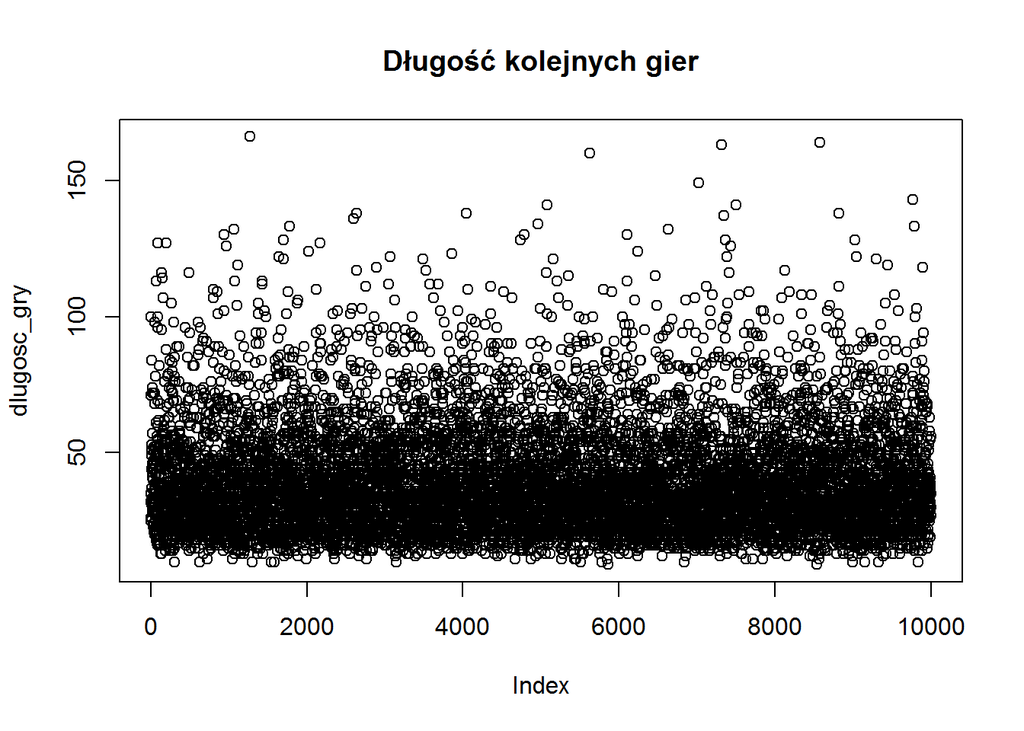

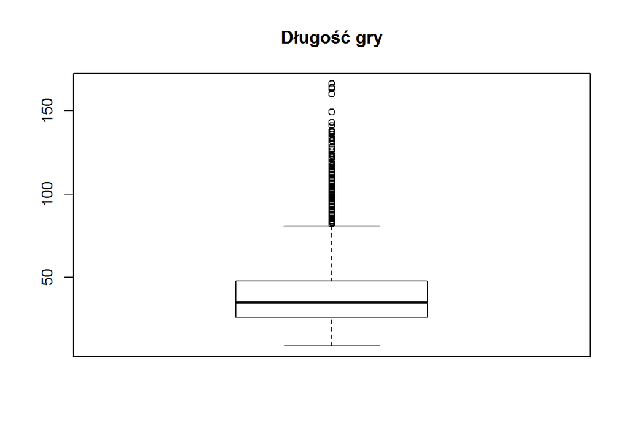